# Prediction Assignment

Jeroen van Rooij

11 juni 2019

## Setup and Downloading Data

```r
library(caret)
library(skimr)
```

```r
library(ggcorrplot)
download.file("https://d396qusza40orc.cloudfront.net/predmachlearn/pml-training.csv", destfile = "training.csv")
download.file("https://d396qusza40orc.cloudfront.net/predmachlearn/pml-testing.csv", destfile = "testing.csv")

training <- read.csv("training.csv")
testing <- read.csv("testing.csv")
```

## Executive summary

This code attempts to predict in which manner a barbell lift has been performed (Class A - E), using 19622 observations.  
The data has been transformed to remove variables with little explanatory value and is transformed into Principal Components. The model itself is a Random Forest with 3-fold cross validation. The training set accuracy is 100%, which may be due to overfitting. However, the prediction on the test set is correct in 19 out of 20 times (95%) - therefore sufficiently accurate.

## Data prep and exploratory analysis

**Remove columns**  
Some columns may have little predictive value.  
* The first few columns are metadata such as index, subject, timestamp and window. These have little predictive value and are removed

```r
metadata <- c(1,2,3,4,5,7)
training <- training[, -metadata]
testing <- testing[, - metadata]
```

```r
# Remove values with exactly 19216 NA's
countna <- sapply(training, function(x) sum(is.na(x)))
training <- training[, countna != 19216]
testing <- testing[, countna != 19216]

# Remove nearzerovars
nearzerovars <- nearZeroVar(training)

# Check which items are removed
summary(training[,nearzerovars])
```

```
##  new_window  kurtosis_roll_belt kurtosis_picth_belt kurtosis_yaw_belt
##  no :19216            :19216             :19216            :19216
##  yes:  406   #DIV/0!  :   10    #DIV/0!  :   32     #DIV/0!:  406
##              -1.908453:    2    47.000000:    4
##              -0.016850:    1    -0.150950:    3
##              -0.021024:    1    -0.684748:    3
##              -0.025513:    1    -1.750749:    3
##              (Other)  :  391    (Other)  :  361
##  skewness_roll_belt skewness_roll_belt.1 skewness_yaw_belt  max_yaw_belt
##           :19216             :19216             :19216            :19216
##  #DIV/0!  :    9    #DIV/0!  :   32      #DIV/0!:  406     -1.1   :   30
##  0.000000 :    4    0.000000 :    4                        -1.4   :   29
##  0.422463 :    2    -2.156553:    3                        -1.2   :   26
##  -0.003095:    1    -3.072669:    3                        -0.9   :   24
##  -0.010002:    1    -6.324555:    3                        -1.3   :   22
##  (Other)  :  389    (Other)  :  361                        (Other):  275
##   min_yaw_belt   amplitude_yaw_belt kurtosis_roll_arm kurtosis_picth_arm
##         :19216          :19216              :19216            :19216
##  -1.1   :   30   #DIV/0!:   10      #DIV/0! :   78    #DIV/0! :   80
##  -1.4   :   29   0.00   :   12      -0.02438:    1    -0.00484:    1
##  -1.2   :   26   0.0000 :  384      -0.04190:    1    -0.01311:    1
##  -0.9   :   24                      -0.05051:    1    -0.02967:    1
##  -1.3   :   22                      -0.05695:    1    -0.07394:    1
##  (Other):  275                      (Other) :  324    (Other) :  322
##  kurtosis_yaw_arm skewness_roll_arm skewness_pitch_arm skewness_yaw_arm
##          :19216           :19216            :19216             :19216
##  #DIV/0! :   11   #DIV/0! :   77    #DIV/0! :   80     #DIV/0! :   11
##  0.55844 :    2   -0.00051:    1    -0.00184:    1     -1.62032:    2
##  0.65132 :    2   -0.00696:    1    -0.01185:    1     0.55053 :    2
##  -0.01548:    1   -0.01884:    1    -0.01247:    1     -0.00311:    1
##  -0.01749:    1   -0.03359:    1    -0.02063:    1     -0.00562:    1
##  (Other) :  389   (Other) :  325    (Other) :  322     (Other) :  389
##  kurtosis_roll_dumbbell kurtosis_picth_dumbbell kurtosis_yaw_dumbbell
##         :19216                 :19216                  :19216
##  #DIV/0!:    5          -0.5464:    2           #DIV/0!:  406
##  -0.2583:    2          -0.9334:    2
##  -0.3705:    2          -2.0833:    2
##  -0.5855:    2          -2.0851:    2
##  -2.0851:    2          -2.0889:    2
##  (Other):  393          (Other):  396
```

[output cut: 25 more lines]

```
##         :19216                :19216                 :19216
##  #DIV/0!:   83         #DIV/0!:   85          #DIV/0!:  406
##  -0.1912:    2         0.0000 :    4
##  -0.4126:    2         -0.6992:    2
##  -0.0004:    1         -0.0113:    1
##  -0.0013:    1         -0.0131:    1
##  (Other):  317         (Other):  313
##  max_yaw_forearm min_yaw_forearm amplitude_yaw_forearm
##         :19216          :19216          :19216
##  #DIV/0!:   84   #DIV/0!:   84   #DIV/0!:   84
##  -1.2   :   32   -1.2   :   32   0.00   :  322
##  -1.3   :   31   -1.3   :   31
##  -1.4   :   24   -1.4   :   24
##  -1.5   :   24   -1.5   :   24
##  (Other):  211   (Other):  211
```

```r
# Remove columns
training <- training[, - nearzerovars]
testing <- testing[, - nearzerovars]
```

** Exploratory Analysis **

After removing the columns, there are still 53 variables remaining. The correlation between these variables could always be of interest. Due to the large number of variables, a heatmap could be more insightful than a table:

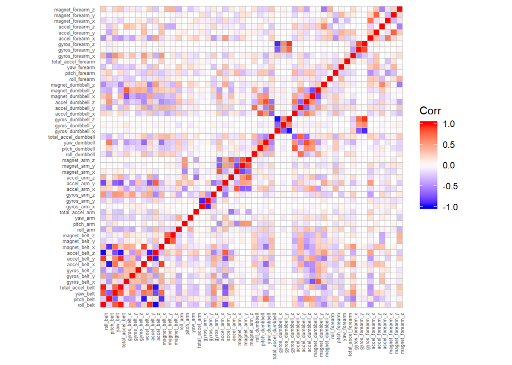

```r
cortable <- round(cor(training[, 1:52]),2)
#cortable[upper.tri(cortable, diag = TRUE)] <- ""
cortable <- as.data.frame(cortable)

ggcorrplot(cortable, method = "square", tl.cex = 5, tl.srt = 90)
```

From the heatmap, it appears that there are some sort of “clusters” that are highly correlated (close to +1 or -1).  
Perhaps the number of variables can be reduced/combined by using Principal Components

## Models

For a prediction model, I have chosen to do a Random Forest. As stated in the previous section, the model is further preprocessed by using PCA.  
The results are then measured using a confusion matrix. Less succesful models can be found in the appendix

```r
modelfit1 <- train(classe ~ . , data = training, preProcess="pca",
                  method = "rf",
                  trControl = trainControl(method = "cv", number = 3, allowParallel = TRUE))
pred1 <- predict(modelfit1, training)
confusionMatrix(pred1, training$classe)
```

```
## Confusion Matrix and Statistics
##
##           Reference
## Prediction    A    B    C    D    E
##          A 5580    0    0    0    0
##          B    0 3797    0    0    0
##          C    0    0 3422    0    0
##          D    0    0    0 3216    0
##          E    0    0    0    0 3607
##
## Overall Statistics
##
##                Accuracy : 1
##                  95% CI : (0.9998, 1)
##     No Information Rate : 0.2844
##     P-Value [Acc > NIR] : < 2.2e-16
##
##                   Kappa : 1
##
##  Mcnemar's Test P-Value : NA
##
## Statistics by Class:
##
##                      Class: A Class: B Class: C Class: D Class: E
## Sensitivity            1.0000   1.0000   1.0000   1.0000   1.0000
## Specificity            1.0000   1.0000   1.0000   1.0000   1.0000
## Pos Pred Value         1.0000   1.0000   1.0000   1.0000   1.0000
## Neg Pred Value         1.0000   1.0000   1.0000   1.0000   1.0000
## Prevalence             0.2844   0.1935   0.1744   0.1639   0.1838
## Detection Rate         0.2844   0.1935   0.1744   0.1639   0.1838
## Detection Prevalence   0.2844   0.1935   0.1744   0.1639   0.1838
## Balanced Accuracy      1.0000   1.0000   1.0000   1.0000   1.0000
```

The results show a 100% accuracy on the training set. However, this may of be due to overfitting of the data. The prediction on the test set is as follows:

```r
prediction1 <- predict(modelfit1, testing[,-53])
print(prediction1)
```

```
##  [1] B A A A A E D B A A B C B A E E A B B B
## Levels: A B C D E
```

This is correct 19/20 times, thus 95%.

```r
#head(training)
#summary(training)
#skimmed <- skim_to_wide(training)
#print(skimmed)

#cor(training)
```

## Appendix

Decision tree

```r
modelfit2 <- train(classe ~ . , data = training, method = "rpart")
pred2 <- predict(modelfit2, training)
accuracy2 <- table(pred2, training$classe)
print(accuracy2)
```

```
##
## pred2    A    B    C    D    E
##     A 5080 1581 1587 1449  524
##     B   81 1286  108  568  486
##     C  405  930 1727 1199  966
##     D    0    0    0    0    0
##     E   14    0    0    0 1631
```

Linear discriminant analysis

```r
modelfit3 <- train(classe ~ . , data = training, method = "lda", preProcess = c("center", "scale"))
pred3 <- predict(modelfit3, training)
accuracy3 <- table(pred3, training$classe)
print(accuracy3)
```

```
##
## pred3    A    B    C    D    E
##     A 4568  586  341  191  133
##     B  121 2429  333  130  611
##     C  444  455 2254  379  323
##     D  429  148  411 2383  344
##     E   18  179   83  133 2196
```